# Reference Quality Scores

Gregg Thomas

## Example read sets

Read set 1

| Reads | A A A A A A A A A A A A A A A A A A A A |
| --- | --- |
| Base qual | 40 40 40 40 40 40 40 40 40 40 40 40 40 40 40 40 40 40 40 1-40 |
| Map qual | 40 40 40 40 40 40 40 40 40 40 40 40 40 40 40 40 40 40 40 1-40 |

Read set 2

| Reads | A A A A A A A A A A A A A A A A A A A T |
| --- | --- |
| Base qual | 40 40 40 40 40 40 40 40 40 40 40 40 40 40 40 40 40 40 40 1-40 |
| Map qual | 40 40 40 40 40 40 40 40 40 40 40 40 40 40 40 40 40 40 40 1-40 |

Read set 3

| Reads | A A A A A A A A A A T T T T T T T T T T |
| --- | --- |
| Base qual | 40 40 40 40 40 40 40 40 40 40 40 40 40 40 40 40 40 40 40 1-40 |
| Map qual | 40 40 40 40 40 40 40 40 40 40 40 40 40 40 40 40 40 40 40 1-40 |

## I. Genotype likelihoods and quality scores (briefly)

$$\mathbb{G} = \{\{A,A\}, \{A,T\}, \{A,C\}, \{A,G\}, \{T,T\}, \{T,C\}, \{T,G\}, \{C,C\}, \{C,G\}, \{G,G\}\}$$

Given a set of reads $R$ at a site, we can calculate the likelihood of each genotype.

**Equation 1**

$$P(R|\mathbb{G} = \{A_1,A_2\}) = \prod_{r}^{R} (\frac{1}{2}P(b_r|A_1) + \frac{1}{2}P(b_r|A_2) )$$

To calculate the probability of the mapped base at the current read $b_r$ given each allele in the genotype $A_i$, we can use the Phred scaled base quality score $Q_b$ and Phred scaled mapping quality score $Q_m$ for that base. First we convert the Phred scale scores into probabilities of error:

**Equation 2**

$$e = 10^{-\frac{Q}{10}}$$

Plugging in $Q_b$ and $Q_m$ gets us $e_b$ and $e_m$, respectively. These are the probabilities of error for both base calling and mapping.

Then we can calculate the probability of the base given an allele $P(b_r|A_i)$ as follows:

**Equation 3**

$$\begin{equation}
P(b_r|A_i) =
\begin{cases}
\frac{(e_s * e_m)}{3} & \text{: $b \neq A_i$}\\
1 - (e_s * e_m) & \text{: $b = A_i$}\\
\end{cases}
\end{equation}$$

The likelihood of each genotype is obtained in this fashion. These likelihoods are then converted back to the Phred scale:

**Equation 4**

$$PL = -10 \log_{10}(P(R|\mathbb{G} = \{A_1,A_2\}))$$

Since these are likelihoods that the genotype is incorrect, the lowest likelihood is the best scoring. This translates to $PL$ as well. Therefore, we obtain a genotype quality score $Q_\mathbb{G}$ by taking the difference between the lowest score and the second lowest score.

**Equation 5**

$$Q_\mathbb{G} = min_2(PL) - min(PL)$$

## II. A reference quality score

Now we wish to compute a similar value for a reference base given a set of reads that map to that position $Q_{ref}$. There are several methods I can think to do this.

### Method 1

First, we could sum up the likelihoods of all genotypes that contain the reference allele ($L_{match}$) and seperately sum up the likelihoods of all the genotypes that do not contain the reference allele ($L_{mismatch}$). For instance, if our reference base was an A, then:

$$L_{match} = P(R|\{A,A\}) + P(R|\{A,T\}) + P(R|\{A,C\}) + P(R|\{A,G\})$$

and:

$$L_{mismatch} = P(R|\{T,T\}) + P(R|\{T,C\}) + P(R|\{T,G\}) + P(R|\{C,C\}) + P(R|\{C,G\}) + P(R|\{G,G\})$$
Then, we could take the difference between these values as $L_{ref}$ and put it on the Phred scale for $Q_{ref}$

**Equation 6**

$$L_{ref} = | L_{mismatch} - L_{match}|$$
The absolute value is necessary because we can’t take the log of negative numbers in the next step.

**Equation 7**

$$Q_{ref} = -10 \log_{10}L_{ref}$$

**Figure 1: Examples of $Q_{ref}$ calculated with Method 1**

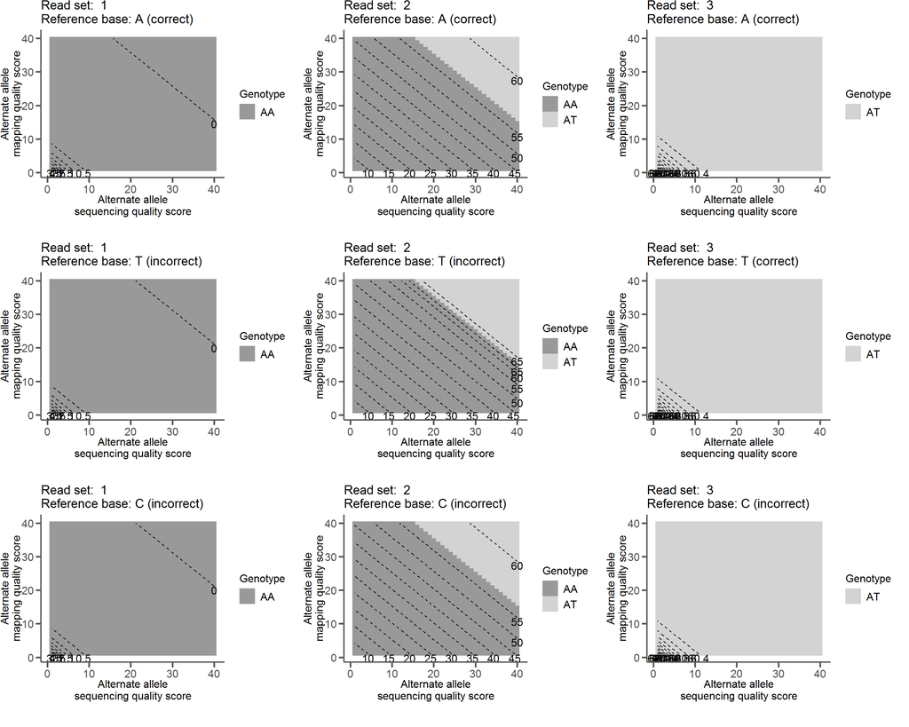

Scores at max base and mapping quality

| read_set | ref_base | ref_type | genotypes | gt_quality | alt_base_quality | alt_map_quality | ref_quality |
| --- | --- | --- | --- | --- | --- | --- | --- |
| 1 | A | (correct) | AA | 60.20600 | 40 | 40 | -0.0000116 |
| 2 | A | (correct) | AT | 24.56521 | 40 | 40 | 60.1908464 |
| 3 | A | (correct) | AT | 787.50613 | 40 | 40 | 60.2059997 |
| 1 | T | (incorrect) | AA | 60.20600 | 40 | 40 | -0.0000033 |
| 2 | T | (incorrect) | AT | 24.56521 | 40 | 40 | 60.2212061 |
| 3 | T | (correct) | AT | 787.50613 | 40 | 40 | 60.2059997 |
| 1 | C | (incorrect) | AA | 60.20600 | 40 | 40 | -0.0000033 |
| 2 | C | (incorrect) | AT | 24.56521 | 40 | 40 | 60.1908465 |
| 3 | C | (incorrect) | AT | 787.50613 | 40 | 40 | 60.2059997 |

Scores at min base and mapping quality

|  | read_set | ref_base | ref_type | genotypes | gt_quality | alt_base_quality | alt_map_quality | ref_quality |
| --- | --- | --- | --- | --- | --- | --- | --- | --- |
| 1600 | 1 | A | (correct) | AA | 58.24727 | 1 | 1 | 4.329216 |
| 16001 | 2 | A | (correct) | AA | 55.80529 | 1 | 1 | 6.771185 |
| 16002 | 3 | A | (correct) | AT | 707.13562 | 1 | 1 | 62.576501 |
| 16003 | 1 | T | (incorrect) | AA | 58.24727 | 1 | 1 | 4.329229 |
| 16004 | 2 | T | (incorrect) | AA | 55.80529 | 1 | 1 | 6.771208 |
| 16005 | 3 | T | (correct) | AT | 707.13562 | 1 | 1 | 62.576501 |
| 16006 | 1 | C | (incorrect) | AA | 58.24727 | 1 | 1 | 4.329229 |
| 16007 | 2 | C | (incorrect) | AA | 55.80529 | 1 | 1 | 6.771202 |
| 16008 | 3 | C | (incorrect) | AT | 707.13562 | 1 | 1 | 62.576501 |

### Method 2

We could also set up a likelihood ratio $LR$ test by divding $L_{mismatch}$ by $L_{match}$ and then Phred scaling this as in **Equation 7**:

**Equation 8**

$$LR = \frac{L_{mismatch}}{L_{match}}$$

**Figure 2: Examples of $Q_{ref}$ calculated with Method 2**

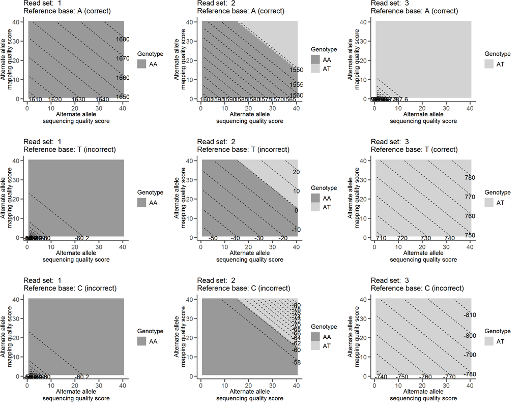

Scores at max base and mapping quality

| read_set | ref_base | ref_type | genotypes | gt_quality | alt_base_quality | alt_map_quality | ref_quality |
| --- | --- | --- | --- | --- | --- | --- | --- |
| 1 | A | (correct) | AA | 60.20600 | 40 | 40 | 1687.64275 |
| 2 | A | (correct) | AT | 24.56521 | 40 | 40 | 1547.45189 |
| 3 | A | (correct) | AT | 787.50613 | 40 | 40 | 787.49765 |
| 1 | T | (incorrect) | AA | 60.20600 | 40 | 40 | -60.20601 |
| 2 | T | (incorrect) | AT | 24.56521 | 40 | 40 | 24.56520 |
| 3 | T | (correct) | AT | 787.50613 | 40 | 40 | 787.49765 |
| 1 | C | (incorrect) | AA | 60.20600 | 40 | 40 | -60.20601 |
| 2 | C | (incorrect) | AT | 24.56521 | 40 | 40 | -81.77607 |
| 3 | C | (incorrect) | AT | 787.50613 | 40 | 40 | -814.59883 |

Scores at min base and mapping quality

|  | read_set | ref_base | ref_type | genotypes | gt_quality | alt_base_quality | alt_map_quality | ref_quality |
| --- | --- | --- | --- | --- | --- | --- | --- | --- |
| 1600 | 1 | A | (correct) | AA | 58.24727 | 1 | 1 | 1605.31352 |
| 16001 | 2 | A | (correct) | AA | 55.80529 | 1 | 1 | 1601.89704 |
| 16002 | 3 | A | (correct) | AT | 707.13562 | 1 | 1 | 789.45156 |
| 16003 | 1 | T | (incorrect) | AA | 58.24727 | 1 | 1 | -58.24728 |
| 16004 | 2 | T | (incorrect) | AA | 55.80529 | 1 | 1 | -55.80530 |
| 16005 | 3 | T | (correct) | AT | 707.13562 | 1 | 1 | 707.12715 |
| 16006 | 1 | C | (incorrect) | AA | 58.24727 | 1 | 1 | -58.24728 |
| 16007 | 2 | C | (incorrect) | AA | 55.80529 | 1 | 1 | -57.19572 |
| 16008 | 3 | C | (incorrect) | AT | 707.13562 | 1 | 1 | -737.23862 |

### Method 3

We could also set up a log likelihood ratio $LLR$ test by subtracting $\log{L_{match}}$ from $\log{L_{mismatch}}$, multiplying by 2, and then Phred scaling this as in **Equation 7**:

**Equation 9**

$$LLR = 2 * (\log{L_{mismatch}} - \log{L_{match}})$$

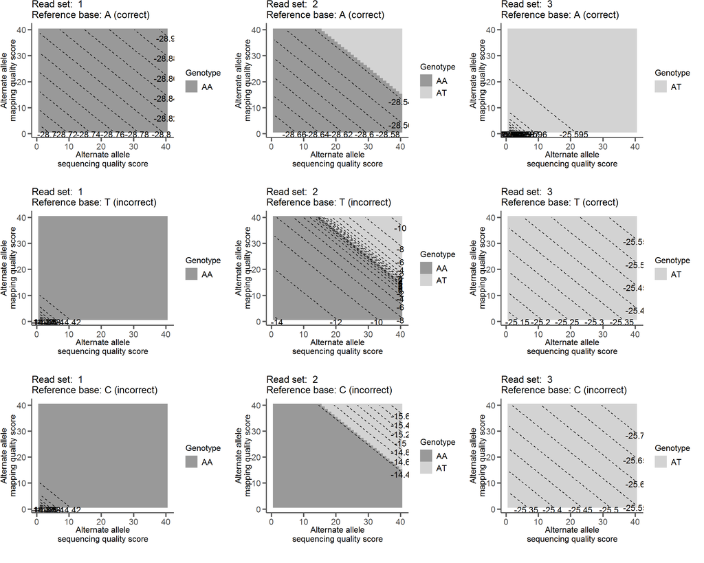

Scores at max base and mapping quality

| read_set | ref_base | ref_type | genotypes | gt_quality | alt_base_quality | alt_map_quality | ref_quality |
| --- | --- | --- | --- | --- | --- | --- | --- |
| 1 | A | (correct) | AA | 60.20600 | 40 | 40 | -28.90526 |
| 2 | A | (correct) | AT | 24.56521 | 40 | 40 | -28.52863 |
| 3 | A | (correct) | AT | 787.50613 | 40 | 40 | -25.59495 |
| 1 | T | (incorrect) | AA | 60.20600 | 40 | 40 | -14.42886 |
| 2 | T | (incorrect) | AT | 24.56521 | 40 | 40 | -10.53566 |
| 3 | T | (correct) | AT | 787.50613 | 40 | 40 | -25.59495 |
| 1 | C | (incorrect) | AA | 60.20600 | 40 | 40 | -14.42886 |
| 2 | C | (incorrect) | AT | 24.56521 | 40 | 40 | -15.75872 |
| 3 | C | (incorrect) | AT | 787.50613 | 40 | 40 | -25.74189 |

Scores at min base and mapping quality

|  | read_set | ref_base | ref_type | genotypes | gt_quality | alt_base_quality | alt_map_quality | ref_quality |
| --- | --- | --- | --- | --- | --- | --- | --- | --- |
| 1600 | 1 | A | (correct) | AA | 58.24727 | 1 | 1 | -28.68806 |
| 16001 | 2 | A | (correct) | AA | 55.80529 | 1 | 1 | -28.67880 |
| 16002 | 3 | A | (correct) | AT | 707.13562 | 1 | 1 | -25.60571 |
| 16003 | 1 | T | (incorrect) | AA | 58.24727 | 1 | 1 | -14.28521 |
| 16004 | 2 | T | (incorrect) | AA | 55.80529 | 1 | 1 | -14.09921 |
| 16005 | 3 | T | (correct) | AT | 707.13562 | 1 | 1 | -25.12743 |
| 16006 | 1 | C | (incorrect) | AA | 58.24727 | 1 | 1 | -14.28521 |
| 16007 | 2 | C | (incorrect) | AA | 55.80529 | 1 | 1 | -14.20609 |
| 16008 | 3 | C | (incorrect) | AT | 707.13562 | 1 | 1 | -25.30854 |

### Method 4

Perhaps we could just take the sum of probabilities of genotypes containing the reference ($L_{match}$), and then Phred scale this as in **Equation 7**:

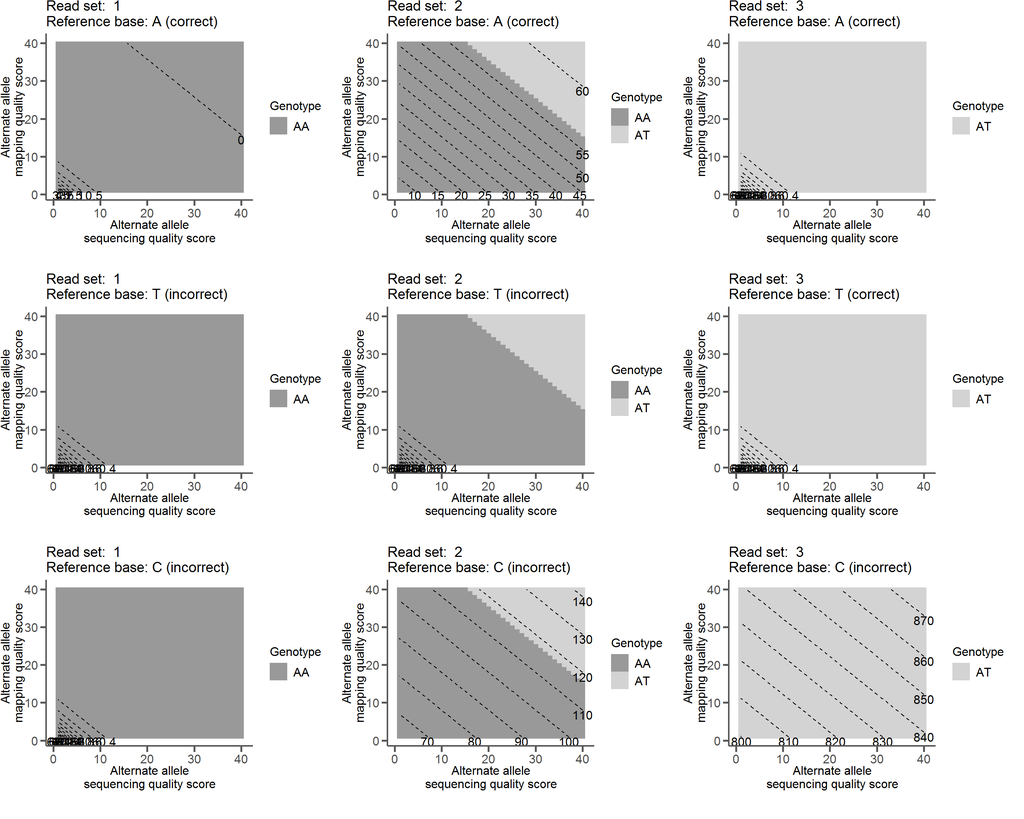

Scores at max base and mapping quality

| read_set | ref_base | ref_type | genotypes | gt_quality | alt_base_quality | alt_map_quality | ref_quality |
| --- | --- | --- | --- | --- | --- | --- | --- |
| 1 | A | (correct) | AA | 60.20600 | 40 | 40 | -0.0000116 |
| 2 | A | (correct) | AT | 24.56521 | 40 | 40 | 60.1908464 |
| 3 | A | (correct) | AT | 787.50613 | 40 | 40 | 60.2059997 |
| 1 | T | (incorrect) | AA | 60.20600 | 40 | 40 | 60.2059997 |
| 2 | T | (incorrect) | AT | 24.56521 | 40 | 40 | 60.2059997 |
| 3 | T | (correct) | AT | 787.50613 | 40 | 40 | 60.2059997 |
| 1 | C | (incorrect) | AA | 60.20600 | 40 | 40 | 60.2059997 |
| 2 | C | (incorrect) | AT | 24.56521 | 40 | 40 | 141.9669123 |
| 3 | C | (incorrect) | AT | 787.50613 | 40 | 40 | 874.8048254 |

Scores at min base and mapping quality

|  | read_set | ref_base | ref_type | genotypes | gt_quality | alt_base_quality | alt_map_quality | ref_quality |
| --- | --- | --- | --- | --- | --- | --- | --- | --- |
| 1600 | 1 | A | (correct) | AA | 58.24727 | 1 | 1 | 4.329216 |
| 16001 | 2 | A | (correct) | AA | 55.80529 | 1 | 1 | 6.771185 |
| 16002 | 3 | A | (correct) | AT | 707.13562 | 1 | 1 | 62.576501 |
| 16003 | 1 | T | (incorrect) | AA | 58.24727 | 1 | 1 | 62.576501 |
| 16004 | 2 | T | (incorrect) | AA | 55.80529 | 1 | 1 | 62.576501 |
| 16005 | 3 | T | (correct) | AT | 707.13562 | 1 | 1 | 62.576501 |
| 16006 | 1 | C | (incorrect) | AA | 58.24727 | 1 | 1 | 62.576501 |
| 16007 | 2 | C | (incorrect) | AA | 55.80529 | 1 | 1 | 63.966912 |
| 16008 | 3 | C | (incorrect) | AT | 707.13562 | 1 | 1 | 799.815125 |

### Method 5

Perhaps we could just take the max of probabilities of genotypes containing the reference ($L_{match}$), and then Phred scale this as in **Equation 7**:

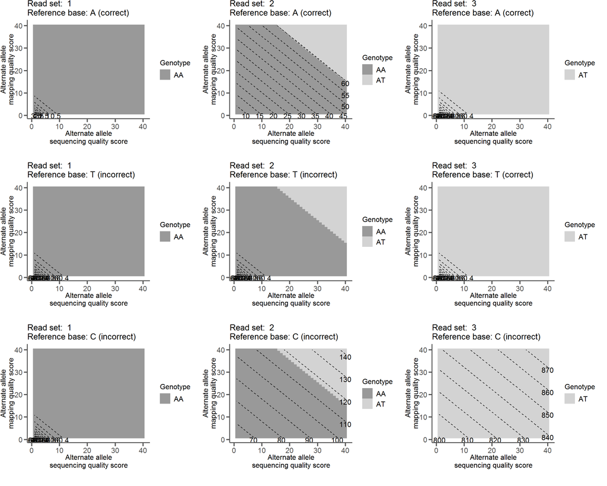

Scores at max base and mapping quality

| read_set | ref_base | ref_type | genotypes | gt_quality | alt_base_quality | alt_map_quality | ref_quality |
| --- | --- | --- | --- | --- | --- | --- | --- |
| 1 | A | (correct) | AA | 60.20600 | 40 | 40 | 0.0000009 |
| 2 | A | (correct) | AT | 24.56521 | 40 | 40 | 60.2059997 |
| 3 | A | (correct) | AT | 787.50613 | 40 | 40 | 60.2059997 |
| 1 | T | (incorrect) | AA | 60.20600 | 40 | 40 | 60.2059997 |
| 2 | T | (incorrect) | AT | 24.56521 | 40 | 40 | 60.2059997 |
| 3 | T | (correct) | AT | 787.50613 | 40 | 40 | 60.2059997 |
| 1 | C | (incorrect) | AA | 60.20600 | 40 | 40 | 60.2059997 |
| 2 | C | (incorrect) | AT | 24.56521 | 40 | 40 | 141.9669123 |
| 3 | C | (incorrect) | AT | 787.50613 | 40 | 40 | 877.8151253 |

Scores at min base and mapping quality

|  | read_set | ref_base | ref_type | genotypes | gt_quality | alt_base_quality | alt_map_quality | ref_quality |
| --- | --- | --- | --- | --- | --- | --- | --- | --- |
| 1600 | 1 | A | (correct) | AA | 58.24727 | 1 | 1 | 4.329235 |
| 16001 | 2 | A | (correct) | AA | 55.80529 | 1 | 1 | 6.771213 |
| 16002 | 3 | A | (correct) | AT | 707.13562 | 1 | 1 | 62.576501 |
| 16003 | 1 | T | (incorrect) | AA | 58.24727 | 1 | 1 | 62.576501 |
| 16004 | 2 | T | (incorrect) | AA | 55.80529 | 1 | 1 | 62.576501 |
| 16005 | 3 | T | (correct) | AT | 707.13562 | 1 | 1 | 62.576501 |
| 16006 | 1 | C | (incorrect) | AA | 58.24727 | 1 | 1 | 62.576501 |
| 16007 | 2 | C | (incorrect) | AA | 55.80529 | 1 | 1 | 63.966912 |
| 16008 | 3 | C | (incorrect) | AT | 707.13562 | 1 | 1 | 799.815125 |